# eQTL

Jeff Leek

## Dependencies

This document depends on the following packages:

```r
  library(devtools)
  library(Biobase)
  library(MatrixEQTL)
```

To install these packages you can use the code (or if you are compiling the document, remove the `eval=FALSE` from the chunk.)

```r
install.packages(c("devtools","MatrixEQTL"))
source("http://www.bioconductor.org/biocLite.R")
biocLite(c("Biobase"))
```

## Download the data

Here we are going to follow along with the tutorial on [MatrixEQTL](http://www.bios.unc.edu/research/genomic_software/Matrix_eQTL/runit.html). First we find the files

```r
base.dir = find.package("MatrixEQTL")
SNP_file_name = paste(base.dir, "/data/SNP.txt", sep="");
expression_file_name = paste(base.dir, "/data/GE.txt", sep="")
covariates_file_name = paste(base.dir, "/data/Covariates.txt", sep="")
output_file_name = tempfile()
```

Next we load the data so we can see it

```r
expr = read.table(expression_file_name,sep="\t",
                  header=T,row.names=1)
expr[1,]
```

```
##         Sam_01 Sam_02 Sam_03 Sam_04 Sam_05 Sam_06 Sam_07 Sam_08 Sam_09
## Gene_01   4.91   4.63   5.18   5.07   5.74   5.09   5.31   5.29   4.73
##         Sam_10 Sam_11 Sam_12 Sam_13 Sam_14 Sam_15 Sam_16
## Gene_01   5.72   4.75   4.54   5.01   5.03   4.84   4.44
```

```r
snps = read.table(SNP_file_name,sep="\t",
                  header=T,row.names=1)
snps[1,]
```

```
##        Sam_01 Sam_02 Sam_03 Sam_04 Sam_05 Sam_06 Sam_07 Sam_08 Sam_09
## Snp_01      2      0      2      0      2      1      2      1      1
##        Sam_10 Sam_11 Sam_12 Sam_13 Sam_14 Sam_15 Sam_16
## Snp_01      1      2      2      1      2      2      1
```

```r
cvrt = read.table(covariates_file_name,sep="\t",
                  header=T,row.names=1)
```

## eQTL is linear regession

The simplest eQTL analysis just computes linear regression models for each SNP/gene pair.

```r
e1 = as.numeric(expr[1,])
s1 = as.numeric(snps[1,])
lm1 = lm(e1 ~ s1)
tidy(lm1)
```

```
##          term   estimate std.error  statistic      p.value
## 1 (Intercept) 4.92967742 0.2137508 23.0627348 1.546033e-12
## 2          s1 0.06387097 0.1386998  0.4604979 6.522304e-01
```

We can visualize the data and the model fits

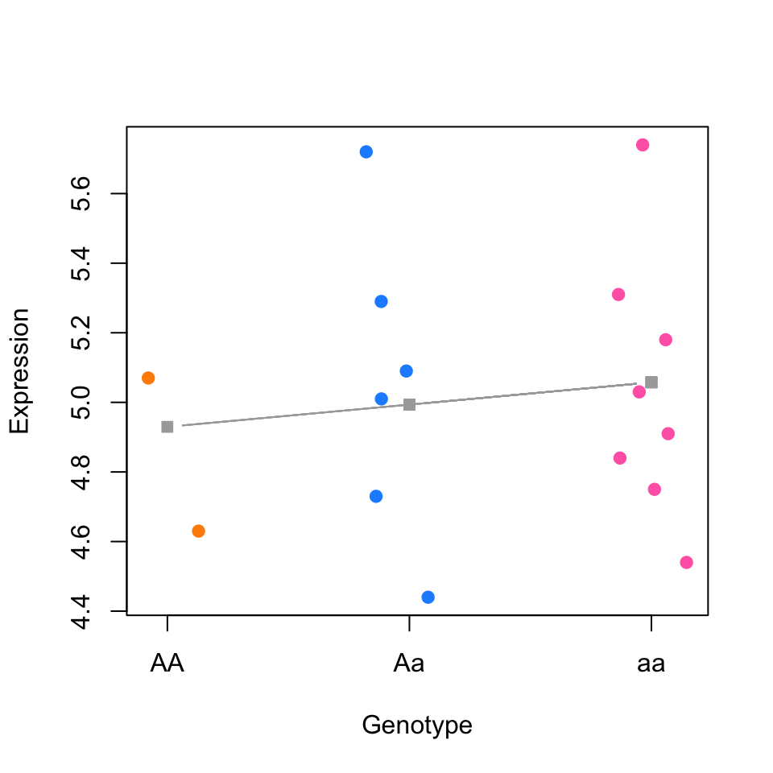

```r
plot(e1 ~ jitter(s1),
     col=(s1+1),xaxt="n",xlab="Genotype",ylab="Expression")
axis(1,at=c(0:2),labels=c("AA","Aa","aa"))
lines(lm1$fitted ~ s1,type="b",pch=15,col="darkgrey")
```

## Fitting many eQTL models with MatrixEQTL

### Set general parameters

We need to set up the p-value cutoff and the error model (in this case assuming independent errors)

```r
pvOutputThreshold = 1e-2
errorCovariance = numeric()
useModel = modelLINEAR
```

### Set the data up

Now we need to set up the snp and gene expression data in the special format required by the `MatrixEQTL` package

```r
snps = SlicedData$new()
snps$fileDelimiter = "\t"     # the TAB character
snps$fileOmitCharacters = "NA" # denote missing values;
snps$fileSkipRows = 1          # one row of column labels
snps$fileSkipColumns = 1       # one column of row labels
snps$fileSliceSize = 2000     # read file in pieces of 2,000 rows
snps$LoadFile( SNP_file_name )
```

```
## Rows read:  15  done.
```

```r
gene = SlicedData$new()
gene$fileDelimiter = "\t"      # the TAB character
gene$fileOmitCharacters = "NA" # denote missing values;
gene$fileSkipRows = 1          # one row of column labels
gene$fileSkipColumns = 1      # one column of row labels
gene$fileSliceSize = 2000      # read file in pieces of 2,000 rows
gene$LoadFile(expression_file_name)
```

```
## Rows read:  10  done.
```

```r
cvrt = SlicedData$new()
```

### Running MatrixEQTL

We can now run the code to calculate the eQTL that we are interested in

```r
me = Matrix_eQTL_engine(
    snps = snps,
    gene = gene,
    cvrt = cvrt,
    output_file_name = NULL,
    pvOutputThreshold = pvOutputThreshold,
    useModel = useModel,
    errorCovariance = errorCovariance,
    verbose = TRUE,
    pvalue.hist = TRUE,
    min.pv.by.genesnp = FALSE,
    noFDRsaveMemory = FALSE);
```

```
## Processing covariates
## Task finished in  0.001  seconds
## Processing gene expression data (imputation, residualization, etc.)
## Task finished in  0.001  seconds
## Creating output file(s)
## Task finished in  0.006  seconds
## Performing eQTL analysis
## 100.00% done, 1 eQTLs
## Task finished in  0.01  seconds
##
```

### Understanding the results

We can make a plot of all the p-values from the tests

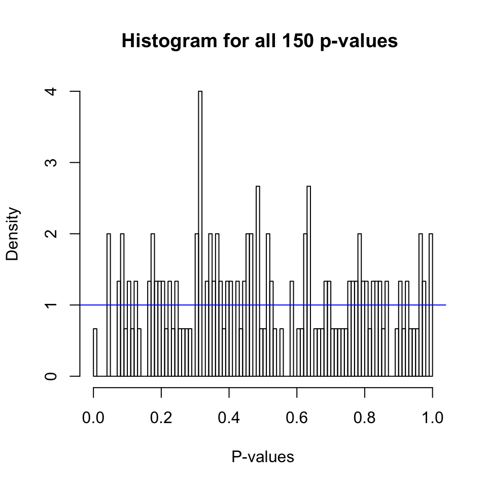

```r
plot(me)
```

We can also figure look at the number and type of eQTL

```r
me$all$neqtls
```

```
## [1] 1
```

```r
me$all$eqtls
```

```
##     snps    gene statistic     pvalue FDR       beta
## 1 Snp_11 Gene_06 -3.007106 0.00941791   1 -0.2916667
```

## More information

eQTL is an entire field of research.

- [MatrixEQTL package](http://www.bios.unc.edu/research/genomic_software/Matrix_eQTL/)
- [MatrixEQTL paper](http://bioinformatics.oxfordjournals.org/content/28/10/1353.abstract?keytype=ref&ijkey=zjMWpHTAUk7OJFw)
- [Surrogate variables applied to eQTL](http://journals.plos.org/plosgenetics/article?id=10.1371/journal.pgen.0030161)
- [A Bayesian sva framework for eQTL](http://journals.plos.org/ploscompbiol/article?id=10.1371/journal.pcbi.1000770)
- [Bioconductor eQTL workflow](http://www.bioconductor.org/help/workflows/eQTL/)

## Session information

```
##  setting  value
##  version  R version 3.2.1 (2015-06-18)
##  system   x86_64, darwin10.8.0
##  ui       RStudio (0.99.447)
##  language (EN)
##  collate  en_US.UTF-8
##  tz       America/New_York
##
##  package           * version     date
##  acepack             1.3-3.3     2014-11-24
##  annotate            1.46.1      2015-07-11
##  AnnotationDbi     * 1.30.1      2015-04-26
##  assertthat          0.1         2013-12-06
##  BiasedUrn         * 1.06.1      2013-12-29
##  Biobase           * 2.28.0      2015-04-17
##  BiocGenerics      * 0.14.0      2015-04-17
##  BiocInstaller     * 1.18.4      2015-07-22
##  BiocParallel        1.2.20      2015-08-07
##  biomaRt             2.24.0      2015-04-17
##  Biostrings          2.36.3      2015-08-12
##  bitops              1.0-6       2013-08-17
##  bladderbatch      * 1.6.0       2015-08-26
##  broom             * 0.3.7       2015-05-06
##  caTools             1.17.1      2014-09-10
##  cluster             2.0.3       2015-07-21
##  colorspace          1.2-6       2015-03-11
##  corpcor             1.6.8       2015-07-08
##  curl                0.9.2       2015-08-08
##  DBI               * 0.3.1       2014-09-24
##  dendextend        * 1.1.0       2015-07-31
##  DESeq2            * 1.8.1       2015-05-02
##  devtools          * 1.8.0       2015-05-09
##  digest              0.6.8       2014-12-31
##  dplyr             * 0.4.3       2015-09-01
##  edge              * 2.1.0       2015-09-06
##  evaluate            0.7.2       2015-08-13
##  foreign             0.8-66      2015-08-19
##  formatR             1.2         2015-04-21
##  Formula           * 1.2-1       2015-04-07
##  futile.logger       1.4.1       2015-04-20
```

[output cut: 181 more lines]

```
##  Bioconductor
##  Bioconductor
##  CRAN (R 3.2.1)
##  CRAN (R 3.2.0)
##  CRAN (R 3.2.1)
##  Bioconductor
##  CRAN (R 3.2.0)
##  CRAN (R 3.2.2)
##  CRAN (R 3.2.0)
##  CRAN (R 3.2.1)
##  CRAN (R 3.2.2)
##  CRAN (R 3.2.0)
##  Bioconductor
##  CRAN (R 3.2.0)
##  Bioconductor
```

It is also useful to compile the time the document was processed. This document was processed on: 2015-09-06.